# Stochastic Gradient Descent algorithms

…on a binary classification problem

Georgios P. Karagiannis @ MATH3431 Machine Learning and Neural Networks III

[Back to README](https://github.com/georgios-stats/Machine_Learning_and_Neural_Networks_III_Epiphany_2025/tree/main?tab=readme-ov-file#computer-lab-notes)

```r
rm(list=ls())
```

*Aim*

- practice in R,
- implement GD, SGD, AdaGrad, SGD with projection, SVRG algorithms in R
- refresh logistic regression, with Ridge penalty from term 1

*Reading material*

- Reference for *R*:
  - [Cheat sheet with basic commands](https://cran.r-project.org/doc/contrib/Short-refcard.pdf)
- Reference of *rmarkdown* (optional, supplementary material):
  - [R Markdown cheatsheet](https://raw.githubusercontent.com/rstudio/cheatsheets/main/rmarkdown-2.0.pdf)
  - [R Markdown Reference Guide](https://www.rstudio.com/wp-content/uploads/2015/03/rmarkdown-reference.pdf)
  - [knitr options](https://yihui.name/knitr/options)
- Reference for *Latex* (optional, supplementary material):
  - [Latex Cheat Sheet](https://wch.github.io/latexsheet/latexsheet-a4.pdf)

*New software*

- R package `base` functions:
  - `set.seed{base}`
- R package `nloptr` functions:
  - `nloptr{nloptr}`
- R package `numDeriv` functions:
  - `grad{numDeriv}`

```r
# call libraries
#install.packages("numDeriv")
library(numDeriv)
#install.packages("nloptr")
library(nloptr)
```

*Initialize R*

```r
# Load R package for printing
library(knitr)
```

```r
# Set a seed of the randon number generator
set.seed(2023)
```

# Application: Binary classification problem

Consider the binary classification problem with input $x\in\mathbb{R}$ and output/labels $y\in\{0,1\}$.

Let $z=\left(y,x\right)$.

Consider data generation process (sampling distribution) $g(\cdot)$

$$y|w \sim \text{Bernulli}(h_{w}(x)) \\
h_{w}(x) = \frac {\exp(w^\top x)}{1+\exp(w^\top x)}$$

We pretend that we do not know $g(\cdot)$.

The routine to simulate $n$ values from the data generation process $g(\cdot)$ is provided below.

```r
data_generating_model <- function(n,w) {
  z <- rep( NaN, times=n*2 )
  z <- matrix(z, nrow = n, ncol = 2)
  z[,1] <- runif(n, min = -10, max = 10)
  p <- w[1] + w[2]*z[,1]
  p <- exp(p) / (1+exp(p))
  z[,2] <- rbinom(n, size = 1, prob = p)
  return(z)
}
```

Consider there is available a training dataset
$$\mathcal{S}_{n}=\left\{ z_{i}=\left(y_{i},x_{i}\right)\right\} _{i=1}^{n}$$

with $y_{i}\in\{0,1\}$ and $x_{i}\in\mathbb{R}$ which is generated according to the data generation process $g(\cdot)$.

Let the training dataset $\mathcal{S}_{n}$ be $n=500$.

Let the real value for the vector of the unknown parameters $w$ be $w_{\text{true}}=(0.0,1.0)^\top$.

The dataset containing the examples to train the model are generated below, and stored in the array $z_{\text{obs}}$.

```r
set.seed(2023)
n_obs <- 500
w_true <- c(0,1)
z_obs <- data_generating_model(n = n_obs, w = w_true)
w_true <- as.numeric(glm(z_obs[,2]~ 1+ z_obs[,1],family = "binomial" )$coefficients)
```

For the learning problem, we consider a prediction rule (hypothesis) with formula
$$h_{w}(x) = \frac {\exp(w^\top x)}{1+\exp(w^\top x)}$$

where $w\in\mathbb{R}^{2}$.

The function **prediction_rule(x,w)** that returns the rule $h$ where $x$ is the input argument and $w$ is the unknown parameter is given below.

```r
prediction_rule <- function(x,w) {
  h <- w[1]+w[2]*x
  h <- exp(h) / (1.0 + exp(h) )
  return (h)
}
```

Hence the hypothesis class is

$$\mathcal{H}=\{w\in\mathbb{R}^{2}\}$$

We consider a loss function

$$\ell\left(w,z=\left(x,y\right)\right)=-y\log\left(h(x)\right)-\left(1-y\right)\log\left(1-h(x)\right)$$

The code for the loss function is provided below as **loss_fun(w,z)** that computes the loss function, where $z=(x,y)$ is one example (observation) and $w$ is the unknown parameter.

```r
loss_fun <- function(w,z) {
  x = z[1]
  y = z[2]
  h <- prediction_rule(x,w)
  ell <- -y*log(h) - (1-y)*log(1-h)
  return (ell)
}
```

The Risk function under the data generation model $g$ is

$$\begin{align*}
R_{g}\left(w\right)= & \text{E}\left(\ell\left(w,z=\left(x,y\right)\right)\right)\\
= & \text{E}\left(-y\log\left(h\left(w;x\right)\right)-\left(1-y\right)\log\left(1-h\left(w;x\right)\right)\right)
\end{align*}$$

The Empirical risk function is
$$\begin{align*}
\hat{R}_{S}\left(w\right) & \frac{1}{n}\sum_{i=1}^{n}\ell\left(w,z_{i}=\left(x_{i},y_{i}\right)\right)\\
= & -\frac{1}{n}\sum_{i=1}^{n}\left(y_{i}\log\left(h(w;x_{i})\right)+\left(1-y\right)\log\left(1-h(w;x_{i})\right)\right)
\end{align*}$$

The function **empirical_risk_fun(w,z,n)** computes the empirical risk, where $z=(x,y)$ is an example, $w$ is the unknown parameter, and $n$ is the data size is given below.

```r
empirical_risk_fun <- function(w,z,n) {
  x = z[,1]
  y = z[,2]
  R <- 0.0
  for (i in 1:n) {
    R <- R + loss_fun(w,z[i,])
  }
  R <- R / n
  return (R)
}
```

# Preparations

Code a function **learning_rate(t,t0)** that computes the learning rate sequence
$$\eta_{t}=\frac{t_0}{t}$$
where $t$ is the iteration stage and $t_0$ is a constant.

Use $t_0=3$ as default value.

```r
learning_rate <-function(t,t0=3) {
  eta <- t0 / t
  return( eta )
}
```

Code the function **grad_loss_fun(w,z)** that returns the gradient of the loss function at parameter value $w$, and at example value $z=(x,y)$.

```r
grad_loss_fun <- function(w,z) {
  x = z[1]
  y = z[2]
  h <- prediction_rule(x,w)
  grd <- c(h-y, (h-y)*x)
  return (grd)
}
```

Code the function **grad_risk_fun <- function(w,z,n)** that returns the gradient of the risk function at parameter value $w$, and using the data set $z$ of size $n\times 2$.

```r
grad_risk_fun <- function(w,z,n) {
  grd <- 0.0
  for (i in 1:n) {
    grd <- grd + grad_loss_fun(w,z[i,])
  }
  grd <- grd / n
  return (grd)
}
```

Compute the gradient of the empirical risk function at point $w=(-0.1,1.5)^\top$.

Use the whole dataset $\{z_{i};i=1,...,n\}$ (set of examples).

Do this by using the command ‘grad_risk_fun’ provided above.

```r
w <- c(-0.1,1.5)
gr <- grad_risk_fun (w, z=z_obs, n=n_obs)
gr
```

```
## [1] -0.005427957  0.045414831
```

## 0.1 Task

```r
w <- c(-0.1,1.5)
#
erf_fun <- function(w, z = z_obs, n=n_obs) {
  return( empirical_risk_fun(w, z, n) )
}
#
gr <- numDeriv::grad( erf_fun, w )
#
gr
```

```
## [1] -0.005427957  0.045414831
```

# 1 Gradient descent

## 1.1 Task

Code a Gradient Descent (GD) algorithm with constant learning rate $\eta_{t}=0.5$ that returns the chain of all the $\{w^{(t)}\}$ produced.

The termination criterion is such that the iterations stop when the the total number of iterations excesses $T=300$.

Use seed $w^{(0)}=(-0.3,3)^\top$.

You may use the R function **grad{numDeriv}** to numerically compute the gradient;

- e.g. numDeriv::grad( erf_fun, w ) .
- Try ?grad for more info.

```r
eta <- 0.5
Tmax <- 300
w_seed <- c(-0.3,3)
w <- w_seed
w_chain <- c()
Qstop <- 0
t <- 0
while ( Qstop == 0 ) {
  # counter
  t <- t +  1
  cat( t ) ; cat( ' ' ) ## counter added for display reasons
  # step 1: update
  erf_fun <- function(w, z = z_obs, n=n_obs) {
    return( empirical_risk_fun(w, z, n) )
  }
  w <- w - eta * numDeriv::grad( erf_fun, w )
  w_chain <- rbind(w_chain, w)
  # step 2: check for termination terminate
  if ( t>= Tmax ) {
    Qstop <- 1
  }
}
```

```
## 1 2 3 4 5 6 7 8 9 10 11 12 13 14 15 16 17 18 19 20 21 22 23 24 25 26 27 28 29 30 31 32 33 34 35 36 37 38 39 40 41 42 43 44 45 46 47 48 49 50 51 52 53 54 55 56 57 58 59 60 61 62 63 64 65 66 67 68 69 70 71 72 73 74 75 76 77 78 79 80 81 82 83 84 85 86 87 88 89 90 91 92 93 94 95 96 97 98 99 100 101 1…
```

```r
# eta <- 0.1
# Tmax <- 1000
# w_seed <- c(-0.1,1.5)
# w <- w_seed
# w_chain <- c()
# Qstop <- 0
# t <- 0
# while ( Qstop == 0 ) {
#   # counter
#   t <- t +  1
#   #eta <- learning_rate( t )
#   # step 1: update
#   w <- w - eta * grad_risk_fun( w, z_obs, n_obs )
#   w_chain <- rbind(w_chain, w)
#   # step 2: check for termination terminate
#   if ( t>= Tmax ) {
#     Qstop <- 1
#   }
# }
```

## 1.2 Task

Plot the chain $\{w_1^{(t)}\}$ against the iteration $t$.

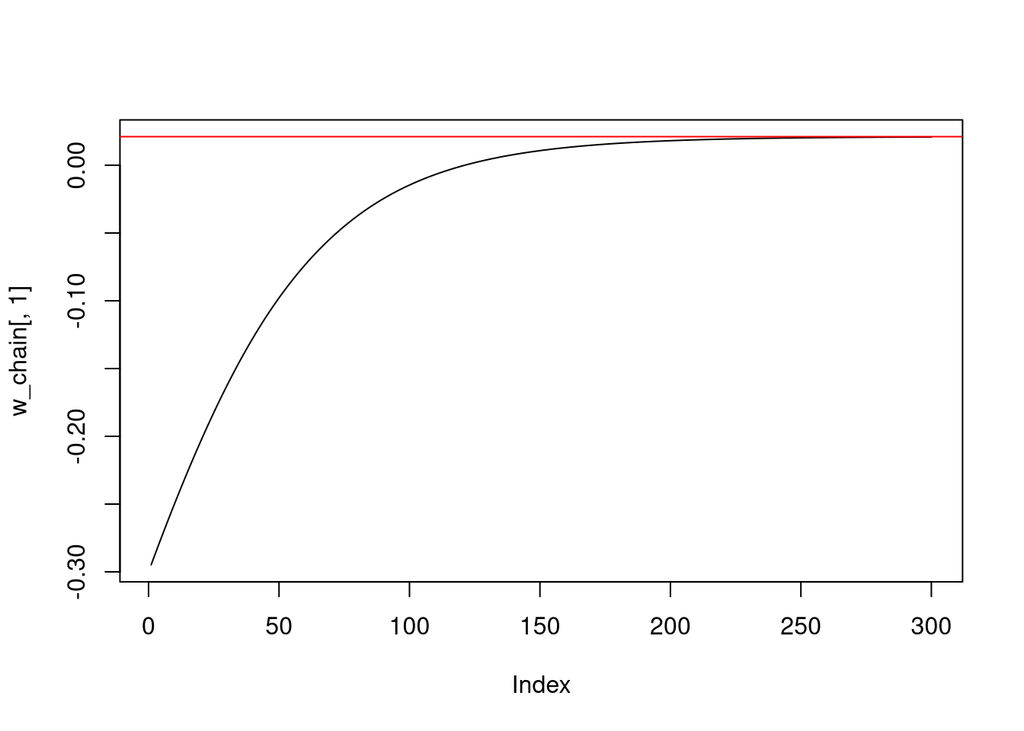

```
## integer(0)
```

```r
plot(w_chain[,1], type='l') +
abline(h=w_true[1], col='red')
```

Plot the chain $\{w_2^{(t)}\}$ against the iteration $t$.

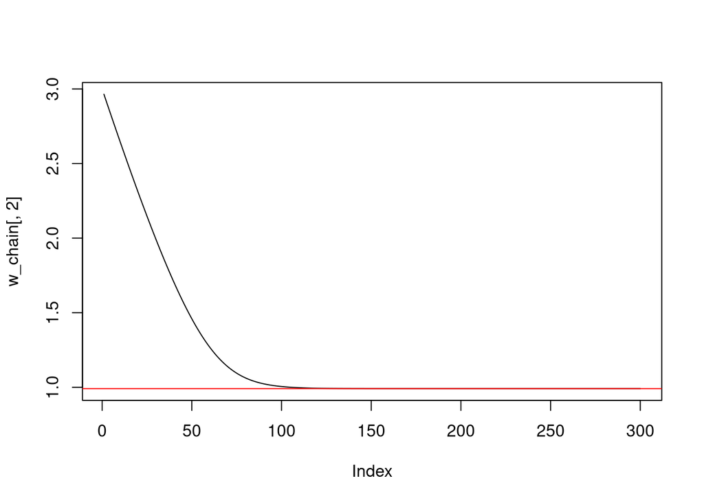

```
## integer(0)
```

```r
plot(w_chain[,2], type='l') +
abline(h=w_true[2], col='red')
```

## 1.3 Task

Re-run the previous GD by changing the algorithmic parameter values for $\eta$ for some in the range $(0.001,1.0)$.

Check how the algorithm behaves by plotting the chains $\{w_1^{(t)}\}$ and $\{w_2^{(t)}\}$ against the iteration $t$.

If necessary change the termination criterion to consider more or less iterations.

```r
#
#
#
```

## 1.4 Task

Re run GD by using a learning rate sequence of the form $\eta_t = t_0/t$ for different values of $t_0>0$ that you will choose.

Check how the algorithm behaves by plotting the chains $\{w_1^{(t)}\}$ and $\{w_2^{(t)}\}$ against the iteration $t$.

If necessary change the termination criterion to consider more or less iterations.

```r
learning_rate <- function(t,t0) {
  return(t0/t)
}
t0<- 10
Tmax <- 300
w_seed <- c(-0.3,3.0)
w <- w_seed
w_chain <- c()
Qstop <- 0
t <- 0
while ( Qstop == 0 ) {
  # counter
  t <- t +  1
  cat( t ) ; cat( ' ' ) ## counter added for display reasons
  # step 1: update
  eta <- learning_rate( t, t0 )
  erf_fun <- function(w, z = z_obs, n=n_obs) {
    return( empirical_risk_fun(w, z, n) )
  }
  w <- w - eta * numDeriv::grad( erf_fun, w )
  #w <- w - eta * grad_risk_fun( w, z_obs, n_obs )
  w_chain <- rbind(w_chain, w)
  # step 2: check for rtermination terminate
  if ( t>= Tmax ) {
    Qstop <- 1
  }
}
```

```
## 1 2 3 4 5 6 7 8 9 10 11 12 13 14 15 16 17 18 19 20 21 22 23 24 25 26 27 28 29 30 31 32 33 34 35 36 37 38 39 40 41 42 43 44 45 46 47 48 49 50 51 52 53 54 55 56 57 58 59 60 61 62 63 64 65 66 67 68 69 70 71 72 73 74 75 76 77 78 79 80 81 82 83 84 85 86 87 88 89 90 91 92 93 94 95 96 97 98 99 100 101 1…
```

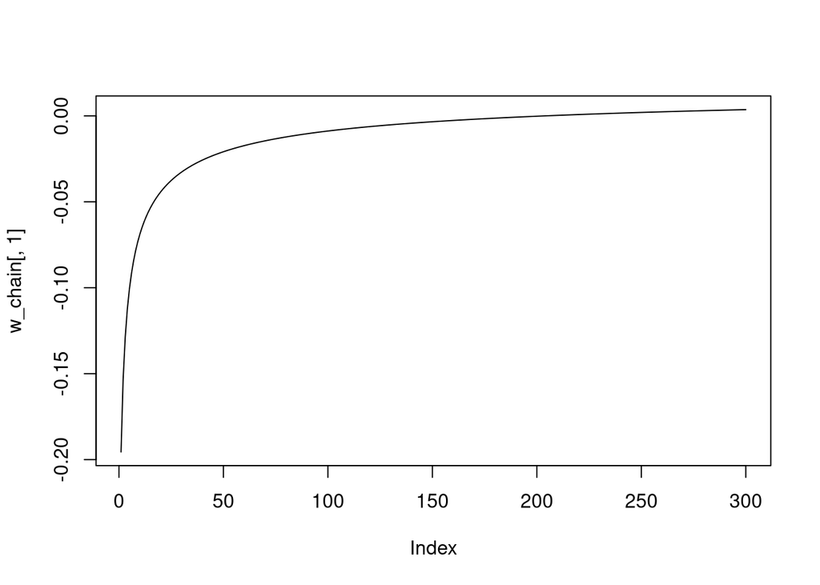

```
## integer(0)
```

```r
plot(w_chain[,1], type='l') +
abline(h=w_true[1], col='red')
```

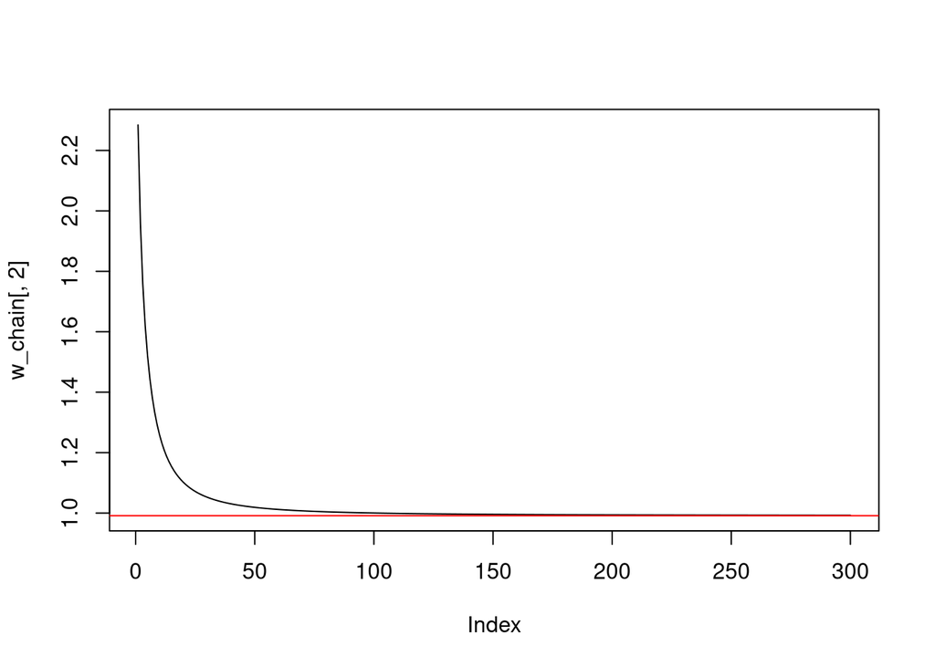

```
## integer(0)
```

```r
plot(w_chain[,2], type='l') +
abline(h=w_true[2], col='red')
```

# 2 Stochastic Gradient Descent

Let the data set $\mathcal{S}_{n}$ has size $n=1000000$.

Assume that the real values for the unknown parameters $w$ is $w_{\text{true}}=(0.0,1.0)^\top$.

The dataset containing the examples to train the model are generated below, and stored in the array $z_{\text{obs}}$.

```r
set.seed(2023)
n_obs <- 1000000
w_true <- c(0,1)
z_obs <- data_generating_model(n = n_obs, w = w_true)
w_true <- as.numeric(glm(z_obs[,2]~ 1+ z_obs[,1],family = "binomial" )$coefficients)
```

## 2.1 Task

Code a Stochastic Gradient Descent (GD) algorithm with learning rate $\eta_{t}=0.5$ and batch size $m=10$ that returns the chain of $\{w^{(t)}\}$.

The sub-sampling may be performed as a sampling with replacement (see ?sample.int).

The termination criterion is when the total number of iterations excesses $T=300$. Seed with $w^{(0)}=(-0.3,3)^\top$.

```r
m <- 10
eta <- 0.5
Tmax <- 300
w_seed <- c(-0.3,3)
w <- w_seed
w_chain <- c()
Qstop <- 0
t <- 0
while ( Qstop == 0 ) {
  # counter
  t <- t +  1
  cat( t ) ; cat( ' ' ) ## counter added for display reasons
  # step 1: update
  J <- sample.int(n = n_obs, size = m, replace = TRUE)
  if (m==1) {
    zbatch <- matrix(z_obs[J,],1,2)
  }
  else {
    zbatch <- z_obs[J,]
  }
  #eta <- learning_rate( t )
  erf_fun <- function(w, z = zbatch, n=m) {
    return( empirical_risk_fun(w, z, n) )
  }
  w <- w - eta * numDeriv::grad( erf_fun, w )
  #w <- w - eta * grad_risk_fun( w, zbatch, m )
  w_chain <- rbind(w_chain, w)
  # step 2: check for rtermination terminate
  if ( t>= Tmax ) {
    Qstop <- 1
  }
}
```

```
## 1 2 3 4 5 6 7 8 9 10 11 12 13 14 15 16 17 18 19 20 21 22 23 24 25 26 27 28 29 30 31 32 33 34 35 36 37 38 39 40 41 42 43 44 45 46 47 48 49 50 51 52 53 54 55 56 57 58 59 60 61 62 63 64 65 66 67 68 69 70 71 72 73 74 75 76 77 78 79 80 81 82 83 84 85 86 87 88 89 90 91 92 93 94 95 96 97 98 99 100 101 1…
```

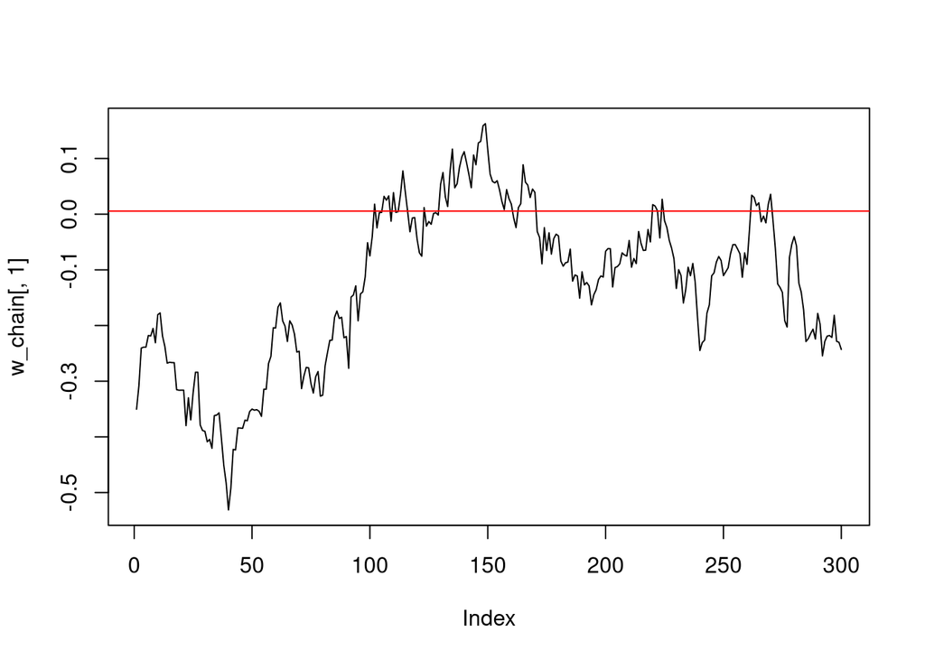

```
## integer(0)
```

```r
plot(w_chain[,1], type='l') +
abline(h=w_true[1], col='red')
```

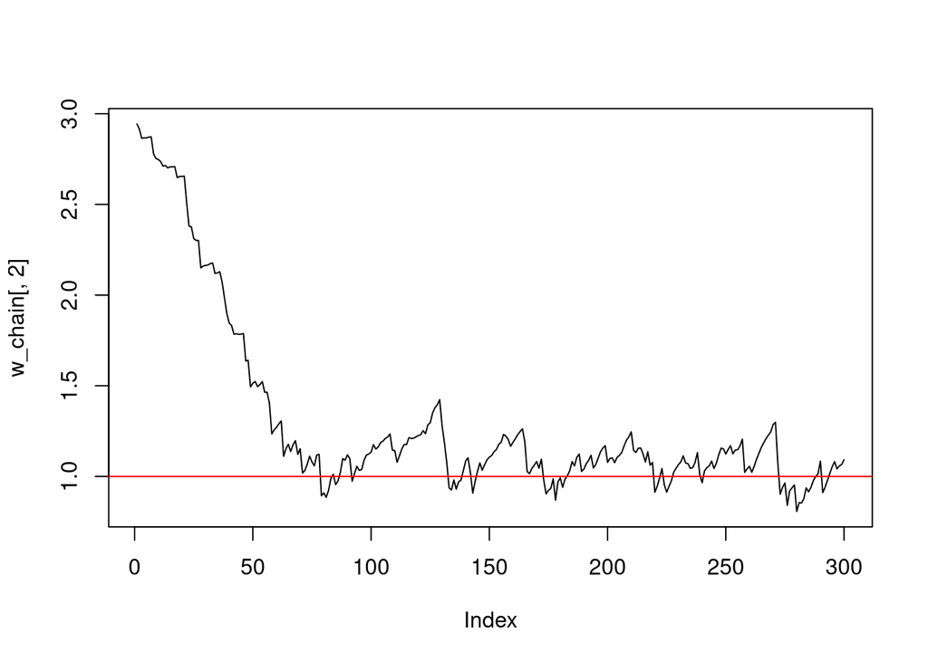

```
## integer(0)
```

```r
plot(w_chain[,2], type='l') +
abline(h=w_true[2], col='red')
```

## 2.2 Task

Re run the SGD by experimenting and changing the values of the learning rate $\eta$ and that of the batch size $m$.

Plot the produced chains of $\{w^{(t)}\}$.

What is the impact of the the learning rate $eta$ and that of the batch size $m$ to the noise and the speed of the convergence ?

```r
m <- 80
eta <- 0.5
Tmax <- 300
w_seed <- c(-0.3,3)
w <- w_seed
w_chain <- c()
Qstop <- 0
t <- 0
while ( Qstop == 0 ) {
  # counter
  t <- t +  1
  cat( t ) ; cat( ' ' ) ## counter added for display reasons
  # step 1: update
  J <- sample.int(n = n_obs, size = m, replace = TRUE)
  if (m==1) {
    zbatch <- matrix(z_obs[J,],1,2)
  }
  else {
    zbatch <- z_obs[J,]
  }
  #eta <- learning_rate( t )
  erf_fun <- function(w, z = zbatch, n=m) {
    return( empirical_risk_fun(w, z, n) )
  }
  w <- w - eta * numDeriv::grad( erf_fun, w )
  #w <- w - eta * grad_risk_fun( w, zbatch, m )
  w_chain <- rbind(w_chain, w)
  # step 2: check for rtermination terminate
  if ( t>= Tmax ) {
    Qstop <- 1
  }
}
```

```
## 1 2 3 4 5 6 7 8 9 10 11 12 13 14 15 16 17 18 19 20 21 22 23 24 25 26 27 28 29 30 31 32 33 34 35 36 37 38 39 40 41 42 43 44 45 46 47 48 49 50 51 52 53 54 55 56 57 58 59 60 61 62 63 64 65 66 67 68 69 70 71 72 73 74 75 76 77 78 79 80 81 82 83 84 85 86 87 88 89 90 91 92 93 94 95 96 97 98 99 100 101 1…
```

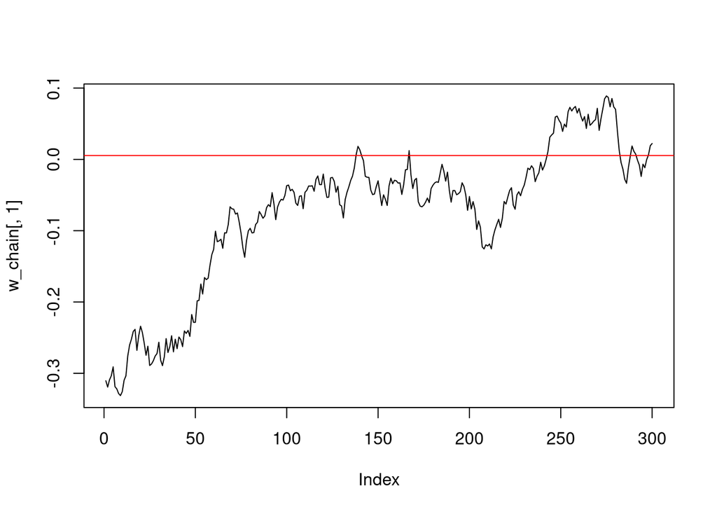

```
## integer(0)
```

```r
#
plot(w_chain[,1], type='l') +
abline(h=w_true[1], col='red')
```

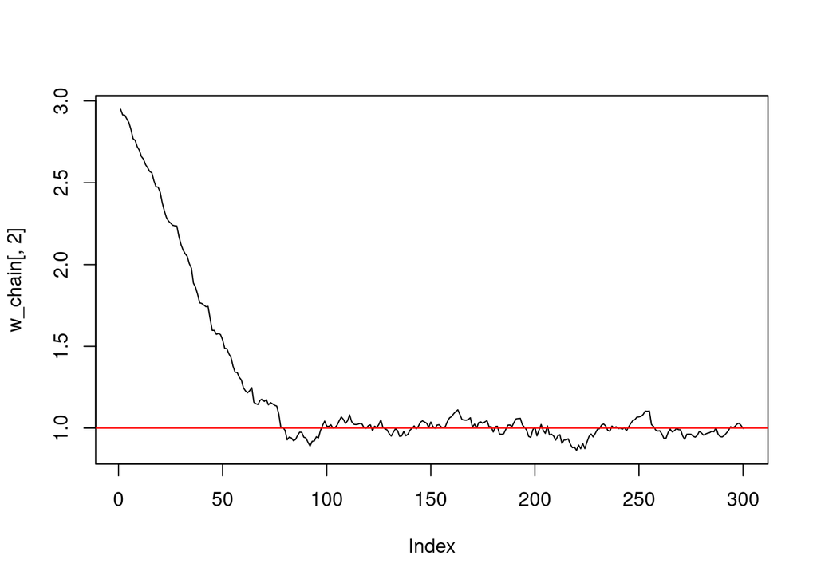

```
## integer(0)
```

```r
#
plot(w_chain[,2], type='l') +
abline(h=w_true[2], col='red')
```

```r
#
```

ANSWER; As discussed in the lectures, the bigger the batch size the smaller the variation of the gradient, hence the error is smaller.

## 2.3 Additional tasks

### 2.3.1 AdaGrad

What would you do it you wish the learning rate to be automatically adjusted?

Practice on the following variation.

- [LINK TO TASKS](https://htmlpreview.github.io/?https://github.com/georgios-stats/Machine_Learning_and_Neural_Networks_III_Epiphany_2025/blob/main/Computer_lab_notes/Stochastic_learning_methods_AdaGrad_tasks.html)
- [LINK TO COMPLETE](https://htmlpreview.github.io/?https://github.com/georgios-stats/Machine_Learning_and_Neural_Networks_III_Epiphany_2025/blob/main/Computer_lab_notes/Stochastic_learning_methods_AdaGrad_complete.html)

### 2.3.2 Projection

What would you do if the parametric space / hypothesis class is constrained?

Practice on the following variation.

- [LINK TO TASKS](https://htmlpreview.github.io/?https://github.com/georgios-stats/Machine_Learning_and_Neural_Networks_III_Epiphany_2025/blob/main/Computer_lab_notes/Stochastic_learning_methods_PrSG_tasks.html)
- [LINK TO COMPLETE](https://htmlpreview.github.io/?https://github.com/georgios-stats/Machine_Learning_and_Neural_Networks_III_Epiphany_2025/blob/main/Computer_lab_notes/Stochastic_learning_methods_PrSG_complete.html)

### 2.3.3 Variance reduction

What would you do it you wanted to reduce the variance of the stochastic gradient?

Practice on the following variation.

- [LINK TO TASKS](https://htmlpreview.github.io/?https://github.com/georgios-stats/Machine_Learning_and_Neural_Networks_III_Epiphany_2025/blob/main/Computer_lab_notes/Stochastic_learning_methods_VRSG_tasks.html)
- [LINK TO COMPLETE](https://htmlpreview.github.io/?https://github.com/georgios-stats/Machine_Learning_and_Neural_Networks_III_Epiphany_2025/blob/main/Computer_lab_notes/Stochastic_learning_methods_VRSG_complete.html)